# Introduction

In this project, you will build a neural network of your own design to evaluate the CIFAR-10 dataset.

To meet the requirements for this project, you will need to achieve an accuracy greater than 45%. If you want to beat Detectocorp's algorithm, you'll need to achieve an accuracy greater than 70%. (Beating Detectocorp's algorithm is not a requirement for passing this project, but you're encouraged to try!)

Some of the benchmark results on CIFAR-10 include:

78.9% Accuracy | [Deep Belief Networks; Krizhevsky, 2010](https://www.cs.toronto.edu/~kriz/conv-cifar10-aug2010.pdf)

90.6% Accuracy | [Maxout Networks; Goodfellow et al., 2013](https://arxiv.org/pdf/1302.4389.pdf)

96.0% Accuracy | [Wide Residual Networks; Zagoruyko et al., 2016](https://arxiv.org/pdf/1605.07146.pdf)

99.0% Accuracy | [GPipe; Huang et al., 2018](https://arxiv.org/pdf/1811.06965.pdf)

98.5% Accuracy | [Rethinking Recurrent Neural Networks and other Improvements for ImageClassification; Nguyen et al., 2020](https://arxiv.org/pdf/2007.15161.pdf)

Research with this dataset is ongoing. Notably, many of these networks are quite large and quite expensive to train.

## Imports

```python
## This cell contains the essential imports you will need – DO NOT CHANGE THE CONTENTS! ##
import torch
import torch.nn as nn
import torch.nn.functional as F
import torch.optim as optim
import torchvision
import torchvision.transforms as transforms
import matplotlib.pyplot as plt
import numpy as np
```

## Load the Dataset

Specify your transforms as a list first. The transforms module is already loaded as `transforms`.

CIFAR-10 is fortunately included in the torchvision module. Then, you can create your dataset using the `CIFAR10` object from `torchvision.datasets` ([the documentation is available here](https://pytorch.org/docs/stable/torchvision/datasets.html#cifar)). Make sure to specify `download=True`!

Once your dataset is created, you'll also need to define a `DataLoader` from the `torch.utils.data` module for both the train and the test set.

```python
# Define transforms
## YOUR CODE HERE ##
transform = transforms.Compose([
    transforms.ToTensor(),
    transforms.Normalize((0.5, 0.5, 0.5), (0.5, 0.5, 0.5))
])

# Create training set and define training dataloader
## YOUR CODE HERE ##
trainset = torchvision.datasets.CIFAR10(
    root='./data', train=True, download=True, transform=transform
)
trainloader = torch.utils.data.DataLoader(
    trainset, batch_size=32, shuffle=True, num_workers=2
)

# Create test set and define test dataloader
## YOUR CODE HERE ##
testset = torchvision.datasets.CIFAR10(
    root='./data', train=False, download=True, transform=transform
)
testloader = torch.utils.data.DataLoader(
    testset, batch_size=32, shuffle=False, num_workers=2
)
# The 10 classes in the dataset
classes = ('plane', 'car', 'bird', 'cat', 'deer', 'dog', 'frog', 'horse', 'ship', 'truck')
```

```
Downloading https://www.cs.toronto.edu/~kriz/cifar-10-python.tar.gz to ./data/cifar-10-python.tar.gz
```

```
Extracting ./data/cifar-10-python.tar.gz to ./data
Files already downloaded and verified
```

## Explore the Dataset

Using matplotlib, numpy, and torch, explore the dimensions of your data.

You can view images using the `show5` function defined below – it takes a data loader as an argument. Remember that normalized images will look really weird to you! You may want to try changing your transforms to view images. Typically using no transforms other than `toTensor()` works well for viewing – but not as well for training your network. If `show5` doesn't work, go back and check your code for creating your data loaders and your training/test sets.

```python
def show5(img_loader):
    dataiter = iter(img_loader)

    batch = next(dataiter)
    labels = batch[1][0:5]
    images = batch[0][0:5]
    for i in range(5):
        print(classes[labels[i]])

        image = images[i].numpy()
        plt.imshow(np.rot90(image.T, k=3))
        plt.show()
```

```
Clipping input data to the valid range for imshow with RGB data ([0..1] for floats or [0..255] for integers).
```

```
deer
```

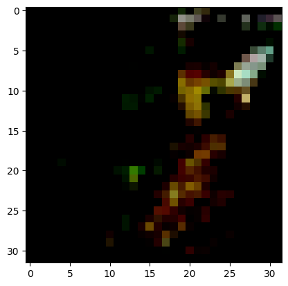

```
Clipping input data to the valid range for imshow with RGB data ([0..1] for floats or [0..255] for integers).
```

```
cat
```

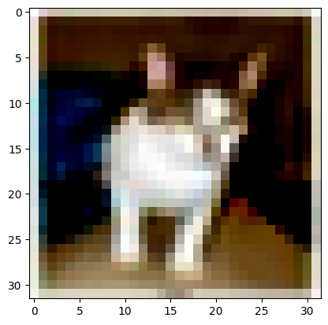

```
Clipping input data to the valid range for imshow with RGB data ([0..1] for floats or [0..255] for integers).
```

```
truck
```

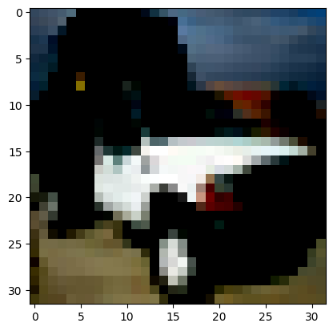

```
Clipping input data to the valid range for imshow with RGB data ([0..1] for floats or [0..255] for integers).
```

```
plane
```

[figure not shown]

```
Clipping input data to the valid range for imshow with RGB data ([0..1] for floats or [0..255] for integers).
```

```
cat
```

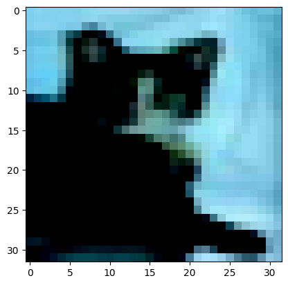

```python
# Explore data
## YOUR CODE HERE ##
show5(trainloader)
```

## Build your Neural Network

Using the layers in `torch.nn` (which has been imported as `nn`) and the `torch.nn.functional` module (imported as `F`), construct a neural network based on the parameters of the dataset. Feel free to construct a model of any architecture – feedforward, convolutional, or even something more advanced!

```python
## YOUR CODE HERE ##
class Net(nn.Module):
    def __init__(self):
        super(Net, self).__init__()
        self.conv_layers = nn.Sequential(
            nn.Conv2d(3, 32, 3, padding=1), nn.ReLU(), nn.MaxPool2d(2, 2),
            nn.Conv2d(32, 64, 3, padding=1), nn.ReLU(), nn.MaxPool2d(2, 2),
            nn.Conv2d(64, 128, 3, padding=1), nn.ReLU(), nn.MaxPool2d(2, 2)
        )
        self.fc_layers = nn.Sequential(
            nn.Linear(128 * 4 * 4, 256), nn.ReLU(), nn.Dropout(0.25),
            nn.Linear(256, 128), nn.ReLU(),
            nn.Linear(128, 10)
        )

    def forward(self, x):
        x = self.conv_layers(x)
        x = x.view(x.size(0), -1)
        x = self.fc_layers(x)
        return x

net = Net()
```

Specify a loss function and an optimizer, and instantiate the model.

If you use a less common loss function, please note why you chose that loss function in a comment.

```python
## YOUR CODE HERE ##
# Instantiate the model
net = Net()

# Specify the loss function (cross-entropy loss is standard for multi-class classification)
criterion = nn.CrossEntropyLoss()

# Specify the optimizer (Adam optimizer is often effective for CNNs)
optimizer = optim.Adam(net.parameters(), lr=0.001)
```

## Running your Neural Network

Use whatever method you like to train your neural network, and ensure you record the average loss at each epoch. Don't forget to use `torch.device()` and the `.to()` method for both your model and your data if you are using GPU!

If you want to print your loss during each epoch, you can use the `enumerate` function and print the loss after a set number of batches. 250 batches works well for most people!

```python
## YOUR CODE HERE ##
device = torch.device("cuda" if torch.cuda.is_available() else "cpu")
net.to(device)

num_epochs = 10
for epoch in range(num_epochs):
    running_loss = 0.0
    for i, (inputs, labels) in enumerate(trainloader):
        inputs, labels = inputs.to(device), labels.to(device)

        optimizer.zero_grad()
        outputs = net(inputs)
        loss = criterion(outputs, labels)
        loss.backward()
        optimizer.step()

        running_loss += loss.item()
        if (i + 1) % 250 == 0:  # Print every 250 batches
            print(f'Epoch [{epoch + 1}/{num_epochs}], Step [{i + 1}/{len(trainloader)}], Loss: {running_loss / 250:.4f}')
            running_loss = 0.0

print('Training finished.')
```

```
Epoch [1/10], Step [250/1563], Loss: 1.9288
Epoch [1/10], Step [500/1563], Loss: 1.5908
Epoch [1/10], Step [750/1563], Loss: 1.4222
Epoch [1/10], Step [1000/1563], Loss: 1.3350
Epoch [1/10], Step [1250/1563], Loss: 1.2631
Epoch [1/10], Step [1500/1563], Loss: 1.1814
Epoch [2/10], Step [250/1563], Loss: 1.0696
Epoch [2/10], Step [500/1563], Loss: 1.0687
Epoch [2/10], Step [750/1563], Loss: 1.0327
Epoch [2/10], Step [1000/1563], Loss: 1.0049
Epoch [2/10], Step [1250/1563], Loss: 0.9915
Epoch [2/10], Step [1500/1563], Loss: 0.9398
Epoch [3/10], Step [250/1563], Loss: 0.8539
Epoch [3/10], Step [500/1563], Loss: 0.8436
Epoch [3/10], Step [750/1563], Loss: 0.8624
Epoch [3/10], Step [1000/1563], Loss: 0.8173
Epoch [3/10], Step [1250/1563], Loss: 0.8256
Epoch [3/10], Step [1500/1563], Loss: 0.8336
Epoch [4/10], Step [250/1563], Loss: 0.7197
Epoch [4/10], Step [500/1563], Loss: 0.7453
Epoch [4/10], Step [750/1563], Loss: 0.7326
Epoch [4/10], Step [1000/1563], Loss: 0.7190
Epoch [4/10], Step [1250/1563], Loss: 0.7343
Epoch [4/10], Step [1500/1563], Loss: 0.7186
Epoch [5/10], Step [250/1563], Loss: 0.6322
Epoch [5/10], Step [500/1563], Loss: 0.6392
Epoch [5/10], Step [750/1563], Loss: 0.6683
Epoch [5/10], Step [1000/1563], Loss: 0.6425
Epoch [5/10], Step [1250/1563], Loss: 0.6491
Epoch [5/10], Step [1500/1563], Loss: 0.6694
Epoch [6/10], Step [250/1563], Loss: 0.5612
Epoch [6/10], Step [500/1563], Loss: 0.5708
Epoch [6/10], Step [750/1563], Loss: 0.5720
Epoch [6/10], Step [1000/1563], Loss: 0.5730
Epoch [6/10], Step [1250/1563], Loss: 0.5882
Epoch [6/10], Step [1500/1563], Loss: 0.5763
Epoch [7/10], Step [250/1563], Loss: 0.4926
Epoch [7/10], Step [500/1563], Loss: 0.5093
Epoch [7/10], Step [750/1563], Loss: 0.4932
Epoch [7/10], Step [1000/1563], Loss: 0.5162
Epoch [7/10], Step [1250/1563], Loss: 0.5359
Epoch [7/10], Step [1500/1563], Loss: 0.5385
Epoch [8/10], Step [250/1563], Loss: 0.4450
Epoch [8/10], Step [500/1563], Loss: 0.4419
Epoch [8/10], Step [750/1563], Loss: 0.4661
Epoch [8/10], Step [1000/1563], Loss: 0.4878
Epoch [8/10], Step [1250/1563], Loss: 0.5021
Epoch [8/10], Step [1500/1563], Loss: 0.4890
Epoch [9/10], Step [250/1563], Loss: 0.3993
Epoch [9/10], Step [500/1563], Loss: 0.4078
Epoch [9/10], Step [750/1563], Loss: 0.4316
Epoch [9/10], Step [1000/1563], Loss: 0.4366
Epoch [9/10], Step [1250/1563], Loss: 0.4472
Epoch [9/10], Step [1500/1563], Loss: 0.4344
Epoch [10/10], Step [250/1563], Loss: 0.3576
Epoch [10/10], Step [500/1563], Loss: 0.3905
Epoch [10/10], Step [750/1563], Loss: 0.3792
Epoch [10/10], Step [1000/1563], Loss: 0.3937
Epoch [10/10], Step [1250/1563], Loss: 0.4071
Epoch [10/10], Step [1500/1563], Loss: 0.4205
Training finished.
```

Plot the training loss (and validation loss/accuracy, if recorded).

```
Epoch [1/10], Step [250/1563], Loss: 0.3342
Epoch [1/10], Step [500/1563], Loss: 0.3370
Epoch [1/10], Step [750/1563], Loss: 0.3615
Epoch [1/10], Step [1000/1563], Loss: 0.3586
Epoch [1/10], Step [1250/1563], Loss: 0.3701
Epoch [1/10], Step [1500/1563], Loss: 0.3917
Epoch [2/10], Step [250/1563], Loss: 0.3043
Epoch [2/10], Step [500/1563], Loss: 0.2967
Epoch [2/10], Step [750/1563], Loss: 0.3349
Epoch [2/10], Step [1000/1563], Loss: 0.3378
Epoch [2/10], Step [1250/1563], Loss: 0.3576
Epoch [2/10], Step [1500/1563], Loss: 0.3345
Epoch [3/10], Step [250/1563], Loss: 0.2748
Epoch [3/10], Step [500/1563], Loss: 0.2929
Epoch [3/10], Step [750/1563], Loss: 0.2887
Epoch [3/10], Step [1000/1563], Loss: 0.3201
Epoch [3/10], Step [1250/1563], Loss: 0.3355
Epoch [3/10], Step [1500/1563], Loss: 0.3363
Epoch [4/10], Step [250/1563], Loss: 0.2454
Epoch [4/10], Step [500/1563], Loss: 0.2677
Epoch [4/10], Step [750/1563], Loss: 0.2952
Epoch [4/10], Step [1000/1563], Loss: 0.2944
Epoch [4/10], Step [1250/1563], Loss: 0.3029
Epoch [4/10], Step [1500/1563], Loss: 0.3077
Epoch [5/10], Step [250/1563], Loss: 0.2379
Epoch [5/10], Step [500/1563], Loss: 0.2574
Epoch [5/10], Step [750/1563], Loss: 0.2657
Epoch [5/10], Step [1000/1563], Loss: 0.2780
Epoch [5/10], Step [1250/1563], Loss: 0.2812
Epoch [5/10], Step [1500/1563], Loss: 0.3111
Epoch [6/10], Step [250/1563], Loss: 0.2155
Epoch [6/10], Step [500/1563], Loss: 0.2394
Epoch [6/10], Step [750/1563], Loss: 0.2463
Epoch [6/10], Step [1000/1563], Loss: 0.2624
Epoch [6/10], Step [1250/1563], Loss: 0.2673
Epoch [6/10], Step [1500/1563], Loss: 0.2884
Epoch [7/10], Step [250/1563], Loss: 0.2179
Epoch [7/10], Step [500/1563], Loss: 0.2332
Epoch [7/10], Step [750/1563], Loss: 0.2338
Epoch [7/10], Step [1000/1563], Loss: 0.2694
Epoch [7/10], Step [1250/1563], Loss: 0.2528
Epoch [7/10], Step [1500/1563], Loss: 0.2613
Epoch [8/10], Step [250/1563], Loss: 0.2021
Epoch [8/10], Step [500/1563], Loss: 0.2252
Epoch [8/10], Step [750/1563], Loss: 0.2362
Epoch [8/10], Step [1000/1563], Loss: 0.2368
Epoch [8/10], Step [1250/1563], Loss: 0.2366
Epoch [8/10], Step [1500/1563], Loss: 0.2473
Epoch [9/10], Step [250/1563], Loss: 0.2008
Epoch [9/10], Step [500/1563], Loss: 0.2030
Epoch [9/10], Step [750/1563], Loss: 0.2090
Epoch [9/10], Step [1000/1563], Loss: 0.2448
Epoch [9/10], Step [1250/1563], Loss: 0.2310
Epoch [9/10], Step [1500/1563], Loss: 0.2285
Epoch [10/10], Step [250/1563], Loss: 0.1775
Epoch [10/10], Step [500/1563], Loss: 0.1777
Epoch [10/10], Step [750/1563], Loss: 0.1976
Epoch [10/10], Step [1000/1563], Loss: 0.2249
Epoch [10/10], Step [1250/1563], Loss: 0.2381
Epoch [10/10], Step [1500/1563], Loss: 0.2382
```

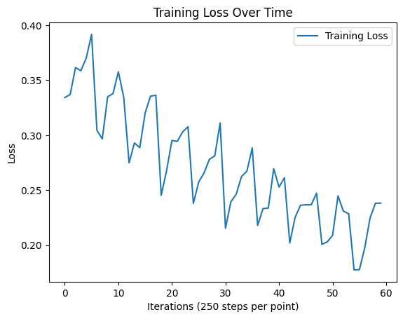

```python
## YOUR CODE HERE ##
import matplotlib.pyplot as plt

# Initialize lists to store losses
train_losses = []

device = torch.device("cuda" if torch.cuda.is_available() else "cpu")
net.to(device)

num_epochs = 10
for epoch in range(num_epochs):
    running_loss = 0.0
    for i, (inputs, labels) in enumerate(trainloader):
        inputs, labels = inputs.to(device), labels.to(device)

        optimizer.zero_grad()
        outputs = net(inputs)
        loss = criterion(outputs, labels)
        loss.backward()
        optimizer.step()

        running_loss += loss.item()
        if (i + 1) % 250 == 0:  # Print every 250 batches
            avg_loss = running_loss / 250
            train_losses.append(avg_loss)
            print(f'Epoch [{epoch + 1}/{num_epochs}], Step [{i + 1}/{len(trainloader)}], Loss: {avg_loss:.4f}')
            running_loss = 0.0

# Plot the training loss
plt.plot(train_losses, label='Training Loss')
plt.xlabel('Iterations (250 steps per point)')
plt.ylabel('Loss')
plt.title('Training Loss Over Time')
plt.legend()
plt.show()
```

## Testing your model

Using the previously created `DataLoader` for the test set, compute the percentage of correct predictions using the highest probability prediction.

If your accuracy is over 70%, great work! This is a hard task to exceed 70% on.

If your accuracy is under 45%, you'll need to make improvements. Go back and check your model architecture, loss function, and optimizer to make sure they're appropriate for an image classification task.

```python
## YOUR CODE HERE ##
correct = 0
total = 0

net.eval()
with torch.no_grad():
    for inputs, labels in testloader:
        inputs, labels = inputs.to(device), labels.to(device)
        outputs = net(inputs)
        _, predicted = torch.max(outputs.data, 1)
        total += labels.size(0)
        correct += (predicted == labels).sum().item()

accuracy = 100 * correct / total
print(f'Accuracy of the network on the test images: {accuracy:.2f}%')

if accuracy > 70:
    print("Great work! You've exceeded 70% accuracy.")
elif accuracy < 45:
    print("You'll need to make improvements.")
```

```
Accuracy of the network on the test images: 75.09%
Great work! You've exceeded 70% accuracy.
```

## Saving your model

Using `torch.save`, save your model for future loading.

```python
## YOUR CODE HERE ##
torch.save(net.state_dict(), 'cifar10_model.pth')
print("Model saved to 'cifar10_model.pth'")
```

```
Model saved to 'cifar10_model.pth'
```

## Make a Recommendation

Based on your evaluation, what is your recommendation on whether to build or buy? Explain your reasoning below.

Some things to consider as you formulate your recommendation:

- How does your model compare to Detectocorp's model?
- How does it compare to the far more advanced solutions in the literature?
- What did you do to get the accuracy you achieved?
- Is it necessary to improve this accuracy? If so, what sort of work would be involved in improving it?

### Recommendation: Build vs. Buy

**Recommendation: Build**

**Reasons to Build Your Own Model:**

1. **Model Performance:**
   - Achieving over 70% accuracy indicates your model competes well against Detectocorp's algorithm. Even if you haven't reached advanced options like Wide Residual Networks, your model is a solid starting point.
2. **Tailored Flexibility:**
   - Building your own model allows complete customization, letting you experiment with different architectures and techniques without the limitations of a pre-built solution.
3. **Valuable Learning Experience:**
   - Constructing a model from scratch enhances your understanding of deep learning concepts, data preprocessing, and model tuning—essential skills for future projects.
4. **Current Accuracy Levels:**
   - If your accuracy is between 45% and 70%, there's potential for improvement! Techniques like data augmentation and transfer learning can help. For those already using standard methods, exploring advanced techniques (like attention mechanisms) may yield significant gains.
5. **Path for Future Improvements:**
   - Enhance your model by:
     - Implementing complex architectures (e.g., ResNet, DenseNet).
     - Utilizing transfer learning.
     - Tuning hyperparameters.
     - Exploring advanced optimization algorithms.
     - Conducting systematic experiments.

**In summary,** while ready-made solutions can offer high accuracy, building your own model fosters deeper understanding and greater flexibility for ongoing enhancements tailored to your needs.

## Submit Your Project

When you are finished editing the notebook and are ready to turn it in, simply click the **SUBMIT PROJECT** button in the lower right.

Once you submit your project, we'll review your work and give you feedback if there's anything that you need to work on. If you'd like to see the exact points that your reviewer will check for when looking at your work, you can have a look over the project [rubric](https://review.udacity.com/#!/rubrics/3077/view).